# Aufgaben

## Aufgaben

#### Aufgabe

1. Im Hinblick auf die lineare Regression: Welche der folgenden Aussage passt am besten?
   1. Die einfache Regression - $y=\alpha + \beta_1x_1 + \epsilon$ - prüft, inwieweit zwei Variablen zusammenhängen (linear oder anderweitig).
   2. Obwohl statistische Zusammenhänge nicht ohne Weiteres Kausalschlüsse erlauben, kann man die Regression für Vorhersagen gut nutzen.
   3. Regressionskoeffizienten kann man so interpretieren: “Erhöht man X um eine 1 Einheit, so steigt daraufhin Y um $\beta_1$ Einheiten” ($\beta_1$ sei der entsprechende Regressionskoeffizient).
   4. “Lineare Regression” bedeutet, dass z.B. keine Polynome wie $y= \alpha + \beta_1 x_1^2 + \beta_2 x_1 + \epsilon$ berechnet werden dürfen, bzw. nicht zur *linearen* Regression zählen.
   5. Zentrieren der Prädiktoren ist bei der linearen Regression nicht zulässig.

#### Aufgabe

2. Welche Aussage zur *multiplen* Regression ist korrekt?
   1. Es sind mehrere Prädiktoren erlaubt, genau dann wenn diese metrisch kontinuierlich sind.
   2. Es sind mehrere Prädiktoren erlaubt, genau dann wenn diese metrisch stetig sind.
   3. Es sind mehrere Prädiktoren erlaubt, genau dann wenn diese *nicht* metrisch kontinuierlich sind.
   4. Es sind mehrere Prädiktoren erlaubt, genau dann wenn diese *nicht* metrisch kontinuierlich sind.
   5. Keine der genannten.

#### Aufgabe

3. Wir betrachten einen Datensatz, der Kredite analysiert. Hier ist ein Auszug:

   ```
   library(openintro)
   data("loans_full_schema")
   ```

   ```
   Rows: 1,292
   Columns: 10
   $ emp_title                 <chr> "security supervisor "…
   $ emp_length                <dbl> 10, 10, 1, 9, 10, 10, …
   $ state                     <fct> CA, MI, NV, AR, NJ, GA…
   $ homeownership             <fct> RENT, MORTGAGE, MORTGA…
   $ annual_income             <dbl> 35000, 35000, 42000, 5…
   $ verified_income           <fct> Verified, Source Verif…
   $ debt_to_income            <dbl> 57.96, 23.66, 32.00, 3…
   $ annual_income_joint       <dbl> 57000, 155000, 95000, …
   $ verification_income_joint <fct> Verified, Not Verified…
   $ debt_to_income_joint      <dbl> 37.66, 13.12, 16.12, 2…
   ```

   [Quelle](http://openintrostat.github.io/openintro/reference/loans_full_schema.html)

   Eine Analystin möchte den Zinssatz (`interest_rate`) auf Basis dieses Datensatzes vorhersagen.

   Welche der oben gezeigten Variablen muss in der Regression *nicht* in Indikatorvariablen umgewandelt werden?
   1. `emp_title`
   2. `state`
   3. `annual_income`
   4. `verified_income`
   5. `verification_income_joint`

#### Aufgabe

4. Wir betrachten einen Datensatz, der Kredite analysiert:

   ```
   library(openintro)
   data("loans_full_schema")
   ```

   [Quelle](http://openintrostat.github.io/openintro/reference/loans_full_schema.html)

   Eine Analystin möchte den Zinssatz (`interest_rate`) auf Basis dieses Datensatzes vorhersagen.

   Welche der Variablen vom Typ `factor` im Datensatz hat genau zwei Stufen (d.h. verschiedene Werte)?
   1. `state`
   2. `homeownership`
   3. `loan_purpose`
   4. `application_type`
   5. `loan_status`

#### Aufgabe

5. Wir betrachten einen Datensatz, der Kredite analysiert:

   ```
   library(openintro)
   data("loans_full_schema")
   ```

   [Quelle](http://openintrostat.github.io/openintro/reference/loans_full_schema.html)

   Eine Analystin möchte den Zinssatz (`interest_rate`) auf Basis dieses Datensatzes vorhersagen.

   Sie berechnet folgendes Regressionsmodell:

   $$R = \beta_0 + \beta_1 I + \beta_2 T$$

   Hier steht $R$ für `interest_rate`, $I$ für `annual_income` und $T$ für `application_type`.

   Wie lautet der R-Befehl, um diese Regression zu berechnen?
   1. `lm(interest_rate ~ annual_income + application_type)`
   2. `lm(interest_rate ~ annual_income + application_type, data = loans_full_schema)`
   3. `lm(R ~ I + T, data = loans_full_schema)`
   4. `lm(interest_rate ~ beta0 + beta1 * annual_income + beta2* application_type, data = loans_full_schema)`
   5. `lm(interest_rate ~ beta0 + beta1 * I + beta2* T, data = loans_full_schema)`

#### Aufgabe

6. Wir betrachten einen Datensatz, der Kredite analysiert:

   ```
   library(openintro)
   data("loans_full_schema")
   ```

   [Quelle](http://openintrostat.github.io/openintro/reference/loans_full_schema.html)

   Hier ist ein Überblick über den Datensatz:

   ```
   ## tibble [10,000 × 3] (S3: tbl_df/tbl/data.frame)
   ##  $ interest_rate   : num [1:10000] 14.07 12.61 17.09 6.72 14.07 ...
   ##  $ annual_income   : num [1:10000] 90000 40000 40000 30000 35000 34000 35000 110000 65000 30000 ...
   ##  $ application_type: Factor w/ 2 levels "individual","joint": 1 1 1 1 2 1 2 1 1 1 ...
   ```

   Eine Analystin möchte den Zinssatz (`interest_rate`) auf Basis dieses Datensatzes vorhersagen.

   Sie berechnet folgendes Regressionsmodell:

   ```
   lm1 <- lm(interest_rate ~ annual_income + application_type, data = loans_full_schema)
   ```

   Folgende Ergebnisse bekommt Sie zurück geliefert:

   | term | estimate | std_error |
   | --- | --- | --- |
   | intercept | 12.90 | 0.083 |
   | annual_income | 0.00 | 0.000 |
   | application_type: joint | 0.71 | 0.140 |

   Welche Aussage ist korrekt?
   1. `Estimate` liefert eine Schätzung zur Modellgüte.
   2. Das Verhältnis von Signal zu Rauschen für `application_typejoint` ist kleiner als 1.
   3. Es liegt ein Fehler vor, denn `application_typejoint` hat neben `joint` noch eine weitere Stufe (`individual`), diese ist aber nicht aufgeführt.
   4. Der Wert bei `Intercept` gibt den Wert der abhängigen Variable an, bei Fällen mit dem Wert `individual` bei `application_type` und ohne Jahreseinkommen.
   5. Der Wert bei `Intercept` gibt den Wert der abhängigen Variable an, bei Fällen mit dem Wert `joint` bei `application_type` und ohne Jahreseinkommen.

#### Aufgabe

7. Wir betrachten einen Datensatz, der Kredite analysiert:

   ```
   library(openintro)
   data("loans_full_schema")
   ```

   [Quelle](http://openintrostat.github.io/openintro/reference/loans_full_schema.html)

   Eine Analystin möchte den Zinssatz (`interest_rate`) auf Basis dieses Datensatzes vorhersagen.

   Sie berechnet folgendes Regressionsmodell (auf einem Teil des Datensatzes):

   ```
   lm1 <- lm(interest_rate ~ annual_income + application_type, data = loans_full_schema)
   ```

   Grafisch aufbereitet, sieht ihr Ergebnis so aus:

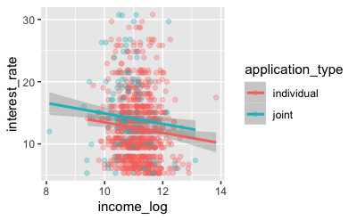

   Welche Aussage ist korrekt?
   1. Für beide Gruppen von `application_type` (`individual` und `joint`) ist die Steigung der Regressionsgerade (annähernd) gleich.
   2. Einkommen wurde logarithmiert; das ist keine sinnvolle Transformation im Allgemeinen.
   3. In diesem Modell gibt es zwei Variablen: Zinssatz und logarithmiertes Einkommen.
   4. In diesem Modell gibt es drei Variablen: Zinssatz, Einkommen und logarithmiertes Einkommen.
   5. In diesem Modell gibt es vier Variablen: Zinssatz, Einkommen, `application_type individual` und `application_type joint`.

#### Aufgabe

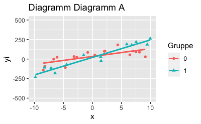

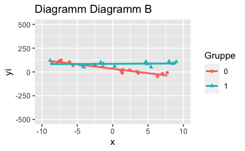

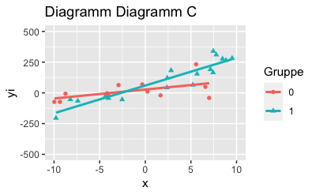

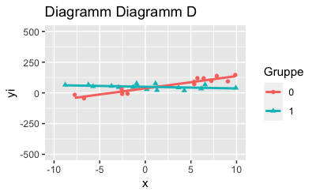

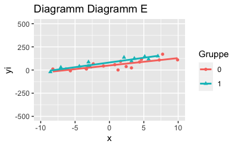

8. Wählen Sie das Diagramm, in dem *kein* Interaktionseffekt (in der Population) vorhanden ist (bzw. wählen Sie Diagramm, dass dies am ehesten darstellt).
   1. Diagramm A
   2. Diagramm B
   3. Diagramm C
   4. Diagramm D
   5. Diagramm E

#### Aufgabe

9. Die Korrelation prüft, ob zwei Merkmale linear zusammenhängen.

   Wie viele andere Verfahren kann die Korrelation als ein Spezialfall der Regression bzw. des linearen Modells $y = \beta_0 + \beta_1 + \ldots \beta_n + \epsilon$ betrachtet werden.

   Als ein spezielles Beispiel betrachten wir die Frage, ob das Gewicht eines Diamanten (`carat`) mit dem Preis (`price`) zusammenhängt (Datensatz `diamonds`).

   Den Datensatz können Sie so laden:

   ```
   library(tidyverse)
   data(diamonds)
   ```

   1. Geben Sie das Skalenniveau beider Variablen an!
   2. Betrachten Sie die Ausgabe von R:

   ```
   lm1 <- lm(price ~ carat, data = diamonds)
   summary(lm1)
   ```

   ```
   ##
   ## Call:
   ## lm(formula = price ~ carat, data = diamonds)
   ##
   ## Residuals:
   ##    Min     1Q Median     3Q    Max
   ## -18585   -805    -19    537  12732
   ##
   ## Coefficients:
   ##             Estimate Std. Error t value Pr(>|t|)
   ## (Intercept)  -2256.4       13.1    -173   <2e-16 ***
   ## carat         7756.4       14.1     551   <2e-16 ***
   ## ---
   ## Signif. codes:  0 '***' 0.001 '**' 0.01 '*' 0.05 '.' 0.1 ' ' 1
   ##
   ## Residual standard error: 1550 on 53938 degrees of freedom
   ## Multiple R-squared:  0.849,  Adjusted R-squared:  0.849
   ## F-statistic: 3.04e+05 on 1 and 53938 DF,  p-value: <2e-16
   ```

   Wie (bzw. wo) ist aus dieser Ausgabe die Korrelation herauszulesen?
   3. Macht es einen Unterschied, ob man Preis mit Karat bzw. Karat mit Preis korreliert?
   4. In der klassischen Inferenzstatistik ist der $p$-Wert eine zentrale Größe; ist er klein ($p<.05$) so nennt man die zugehörige Statistik *signifikant* und verwirft die getestete Hypothese.
   5. Im Folgenden sehen Sie einen Korrelationstest auf statistische Signifikanz, mit R durchgeführt. Zeigt der Test ein (statistisch) signifikantes Ergebnis? Wie groß ist der “Unsicherheitskorridor”, um den Korrelationswert (zugleich Punktschätzer für den Populationswert)?

   ```
   library(rstatix)
   diamonds %>%
     sample_n(30) %>%
     select(price, carat) %>%
     rstatix::cor_test() %>%
     gt()
   ```

   | var1 | var2 | cor | statistic | p | conf.low | conf.high | method |
   | --- | --- | --- | --- | --- | --- | --- | --- |
   | price | carat | 0.84 | 8.3 | 5.6e-09 | 0.69 | 0.92 | Pearson |

#### Aufgabe

10. Laden Sie den Datensatz `mtcars` aus [dieser Quelle](https://vincentarelbundock.github.io/Rdatasets/csv/datasets/mtcars.csv).

    Berechnen Sie eine Regression mit `mpg` als Ausgabevariable und `hp` aus Eingabevariable!

    Welche Aussage ist für diese Analyse richtig?
    1. `mpg` und `hp` sind positiv korreliert laut dem Modell.
    2. Der Achsenabschnitt ist nahe Null.
    3. Die Analyse beinhaltet einen nominal skalierten Prädiktor.
    4. Das geschätzte Betagewicht für `hp` liegt bei `30.099`.
    5. Das geschätzte Betagewicht für `hp` liegt bei `-0.068`.

#### Aufgabe

11. Ist es möglich, kategorial skalierte Prädiktoren in eine Regressionsanalyse (lineare Modell) aufzunehmen?
    1. Ja
    2. Nein
    3. Nur nominal skalierte, nicht ordinal skalierte
    4. Nur ordinal skalierte, nicht nominal skalierte
    5. Ja, aber nur eine

#### Aufgabe

12. Betrachten wir folgende Regressionsmodell:

    $y= \alpha + \beta_1 x + \epsilon$

    Geben Sie eine mathematische Formel an zur Zentrierung der Prädiktoren bzw. des Prädiktors!

    *Hinweise*: - Geben Sie nur eine Formel ein, keinen Text, keine Leerzeichen und keine Sonderzeichen. - Verwenden Sie das Suffix “_c”, um eine zentrierte Variable zu benennen. - Auf Funktionen wie den Mittelwert dürfen Sie zurückgreifen. Um den Mittelwert der Variablen `var` zu spezifizieren, kennzeichnen Sie dies mit `mw(var)`. - Verzichten Sie auf ein Malzeichen bei Multiplikationen. - Beispiel: “y_c = 2 mw(x) - 1”.

#### Aufgabe

13. Zwei Modelle, `m1` und `m2` produzieren jeweils die gleiche Vorhersage (den gleichen Punktschätzer).

    `m1`:

    ```
    ##
    ## Call:
    ## lm(formula = y ~ x)
    ##
    ## Residuals:
    ##     Min      1Q  Median      3Q     Max
    ## -0.2124 -0.0581 -0.0011  0.0651  0.3414
    ##
    ## Coefficients:
    ##             Estimate Std. Error t value Pr(>|t|)
    ## (Intercept) 0.000201   0.009498    0.02     0.98
    ## x           0.994614   0.009127  108.97   <2e-16 ***
    ## ---
    ## Signif. codes:  0 '***' 0.001 '**' 0.01 '*' 0.05 '.' 0.1 ' ' 1
    ##
    ## Residual standard error: 0.093 on 98 degrees of freedom
    ## Multiple R-squared:  0.992,  Adjusted R-squared:  0.992
    ## F-statistic: 1.19e+04 on 1 and 98 DF,  p-value: <2e-16
    ```

    `m2`:

    ```
    ##
    ## Call:
    ## lm(formula = y ~ x)
    ##
    ## Residuals:
    ##    Min     1Q Median     3Q    Max
    ## -2.506 -0.687  0.002  0.716  2.632
    ##
    ## Coefficients:
    ##             Estimate Std. Error t value Pr(>|t|)
    ## (Intercept)   0.0283     0.1060    0.27     0.79
    ## x             0.8585     0.0990    8.67  9.1e-14 ***
    ## ---
    ## Signif. codes:  0 '***' 0.001 '**' 0.01 '*' 0.05 '.' 0.1 ' ' 1
    ##
    ## Residual standard error: 1.1 on 98 degrees of freedom
    ## Multiple R-squared:  0.434,  Adjusted R-squared:  0.429
    ## F-statistic: 75.2 on 1 and 98 DF,  p-value: 9.07e-14
    ```

    Die Modelle unterscheiden sich aber in ihrer Ungewissheit bezüglich $\beta$, wie in der Spalte `Std. Error` ausgedrückt.

    Welches der beiden Modelle ist zu bevorzugen? Begründen Sie.

#### Aufgabe

14. Ein Streudiagramm von $x$ und $y$ ergibt folgende Abbildung; dabei wird noch die Gruppierungsvariable $g$ (mit den Stufen `0` und `1`) berücksichtigt (vgl. Farbe und Form der Punkte). Zur besseren Orientierung ist die Regressionsgerade pro Gruppe eingezeichnet.

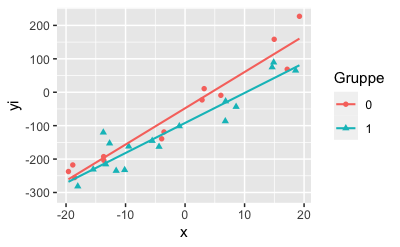

    Wählen Sie das (für die Population) am besten passende Modell aus der Liste aus!

    *Hinweis*: Ein Interaktionseffekt der Variablen $x$ und $g$ ist mit $xg$ gekennzeichnet.
    1. $y = -40 + -10\cdot x + 40 \cdot g + -10 \cdot xg + \epsilon$
    2. $y = -40 + 10\cdot x + 0 \cdot g + 10 \cdot xg + \epsilon$
    3. $y = 40 + -10\cdot x + 0 \cdot g + 10 \cdot xg + \epsilon$
    4. $y = -40 + 10\cdot x + -40 \cdot g + 0 \cdot xg + \epsilon$

#### Aufgabe

15. Berechnen Sie $\hat{y}$ für das unten ausgegeben Modell!

    Nutzen Sie dafür folgende Werte:
    - $g=0$
    - $x=4$.

    | term | estimate | std_error | statistic | p_value | lower_ci | upper_ci |
    | --- | --- | --- | --- | --- | --- | --- |
    | intercept | -34.5 | 4.76 | -7.2 | 0 | -44.0 | -25 |
    | x | 10.6 | 0.88 | 12.1 | 0 | 8.9 | 12 |
    | g | -35.4 | 6.60 | -5.4 | 0 | -48.6 | -22 |
    | x:g | 8.9 | 1.16 | 7.6 | 0 | 6.5 | 11 |

    *Hinweis*: Ein Interaktionseffekt der Variablen $x$ und $g$ ist mit `x:g` gekennzeichnet. Runden Sie zur nächsten ganzen Zahl.

#### Aufgabe

    Wie lautet das Kriterium $y$ für eine Person mit folgenden Werten:
    - $x_1$: 1
    - $x_2$: -1.51
    - $x_3$: -0.8

    Berechnen Sie dazu ein Regressionsmodell (Least Squares) anhand folgender Modellparameter:
    - $\beta_0: 30$
    - $\beta_1: 30$
    - $\beta_2: 1$
    - $\beta_3: 5$
    - $\beta_4: 1$

    Geben Sie als Antwort den vorhergesagten $Y$-Wert an!

    *Hinweis*: Runden Sie auf zwei Dezimalstellen.

#### Aufgabe

17. Die beiden folgenden Abbildungen zeigen zwei lineare Regressionen.

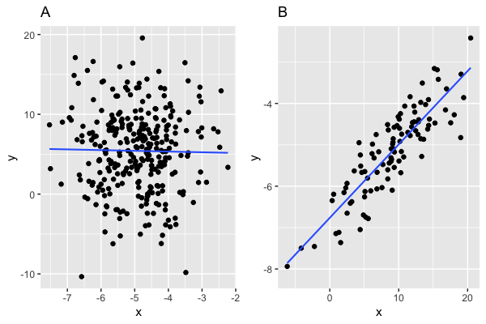

    Welche Aussage stimmt?
    1. $R^2_A < R^2_B$
    2. $R^2_A \approx R^2_B$
    3. $R^2_A > R^2_B$